# applied_statistics_project

```python
import numpy as np
import pandas as pd

import matplotlib.pyplot as plt
import seaborn as sns

%matplotlib inline

from scipy import stats
```

Part C: • DOMAIN: Startup ecosystem • CONTEXT: Company X is a EU online publisher focusing on the startups industry. The company specifically reports on the business related to technology news, analysis of emerging trends and profiling of new tech businesses and products. Their event i.e. Startup Battlefield is the world’s pre-eminent startup competition. Startup Battlefield features 15-30 top early stage startups pitching top judges in front of a vast live audience, present in person and online. • DATA DESCRIPTION: CompanyX_EU.csv - Each row in the dataset is a Start-up company and the columns describe the company. • DATA DICTIONARY:

1. Startup: Name of the company
2. Product: Actual product
3. Funding: Funds raised by the company in USD
4. Event: The event the company participated in
5. Result: Described by Contestant, Finalist, Audience choice, Winner or Runner up
6. OperatingState: Current status of the company, Operating ,Closed, Acquired or IPO *Dataset has been downloaded from the internet. All the credit for the dataset goes to the original creator of the data. PROJECT OBJECTIVE: Analyse the data of the various companies from the given dataset and perform the tasks that are specified in the below steps. Draw insights from the various attributes that are present in the dataset, plot distributions, state hypotheses and draw conclusions from the dataset.
1. Read the CSV file.

```python
# PARTC: 1. Read the CSV file.
company = pd.read_csv('CompanyX_EU.csv')
```

```python
company.head()
```

[output not shown]

```python
company.shape
```

```
(662, 6)
```

1. Data Exploration: A. Check the datatypes of each attribute. B. Check for null values in the attributes.

```python
# PART C
# 2. Data Exploration:
# A. Check the datatypes of each attribute.
# B. Check for null values in the attributes.
company.info()
```

```
<class 'pandas.core.frame.DataFrame'>
RangeIndex: 662 entries, 0 to 661
Data columns (total 6 columns):
 #   Column          Non-Null Count  Dtype
---  ------          --------------  -----
 0   Startup         662 non-null    object
 1   Product         656 non-null    object
 2   Funding         448 non-null    object
 3   Event           662 non-null    object
 4   Result          662 non-null    object
 5   OperatingState  662 non-null    object
dtypes: object(6)
memory usage: 31.2+ KB
```

```python
company.describe()
```

|  | Startup | Product | Funding | Event | Result | OperatingState |
| --- | --- | --- | --- | --- | --- | --- |
| count | 662 | 656 | 448 | 662 | 662 | 662 |
| unique | 662 | 656 | 240 | 26 | 5 | 4 |
| top | 2600Hz | 2600hz.com | $1M | TC50 2008 | Contestant | Operating |
| freq | 1 | 1 | 17 | 52 | 488 | 465 |

1. Data preprocessing & visualisation: [4 Marks] A. Drop the null values. [1 Mark] B. Convert the ‘Funding’ features to a numerical value. (Execute below code) df1.loc[:,'Funds_in_million'] = df1['Funding'].apply(lambda x: float(x[1:-1])/1000 if x[-1] == 'K' else (float(x[1:-1])*1000 if x[-1] == 'B' else float(x[1:-1]))) C. Plot box plot for funds in million. [1 Mark] D. Check the number of outliers greater than the upper fence. [1 Mark] E. Check frequency of the OperatingState features classes. [1 Mark]

```python
# PART C
# 3. Data preprocessing & visualisation:
# A. Drop the null values.
print(company.isnull().sum()) # checked null values are there or not
company.dropna(inplace=True)
company.isnull().sum() # checked null values removed or not
```

```
Startup             0
Product             6
Funding           214
Event               0
Result              0
OperatingState      0
dtype: int64
```

```
Startup           0
Product           0
Funding           0
Event             0
Result            0
OperatingState    0
dtype: int64
```

```python
# PART C
# 3. Data preprocessing & visualisation:
# B. Convert the ‘Funding’ features to a numerical value. (Execute below code) df1.loc[:,'Funds_in_million'] = df1['Funding'].apply(lambda x: float(x[1:-1])/1000 if x[-1] == 'K' else (float(x[1:-1])*1000 if x[-1] == 'B' else float(x[1:-1])))
company.loc[:,'Funds_in_million'] = company['Funding'].apply(lambda x: float(x[1:-1])/1000 if x[-1] == 'K' else (float(x[1:-1])*1000 if x[-1] == 'B' else float(x[1:-1])))
company.info()
```

```
<class 'pandas.core.frame.DataFrame'>
Int64Index: 446 entries, 1 to 661
Data columns (total 7 columns):
 #   Column            Non-Null Count  Dtype
---  ------            --------------  -----
 0   Startup           446 non-null    object
 1   Product           446 non-null    object
 2   Funding           446 non-null    object
 3   Event             446 non-null    object
 4   Result            446 non-null    object
 5   OperatingState    446 non-null    object
 6   Funds_in_million  446 non-null    float64
dtypes: float64(1), object(6)
memory usage: 27.9+ KB
```

```python
company.head()
```

|  | Startup | Product | Funding | Event | Result | OperatingState | Funds_in_million |
| --- | --- | --- | --- | --- | --- | --- | --- |
| 1 | 3DLT | 3dlt.com | $630K | Disrupt NYC 2013 | Contestant | Closed | 0.63 |
| 3 | 3Dprintler | 3dprintler.com | $1M | Disrupt NY 2016 | Audience choice | Operating | 1.00 |
| 5 | 5to1 | 5to1.com | $19.3M | TC50 2009 | Contestant | Acquired | 19.30 |
| 6 | 8 Securities | 8securities.com | $29M | Disrupt Beijing 2011 | Finalist | Operating | 29.00 |
| 10 | AdhereTech | adheretech.com | $1.8M | Hardware Battlefield 2014 | Contestant | Operating | 1.80 |

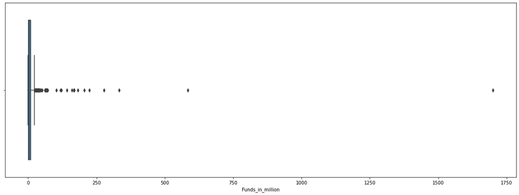

```python
# PART C
# 3.Data preprocessing & visualisation:
# C. Plot box plot for funds in million.
# D. Check the number of outliers greater than the upper fence.
plt.figure(figsize=(20,7))
sns.boxplot(data = company, x = 'Funds_in_million');
```

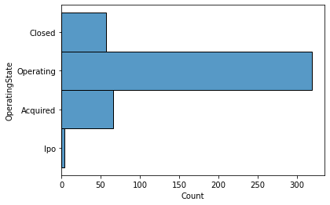

```python
# PART C
# 3. Data preprocessing & visualisation:
# E. Check frequency of the OperatingState features classes.
sns.histplot(data=company,y='OperatingState');
```

[figure not shown]

```python
# PART C
# 4. Statistical Analysis:
# A. Is there any significant difference between Funds raised by companies that are still operating vs companies that closed down?
plt.figure(figsize=(20,10))
sns.countplot(data=company,y='OperatingState', hue='Funds_in_million');
```